# CURSO DE ACTUALIZACION EN ESTADISTICA

#### Profesor: Dr. José Manuel MAGALLANES, Ph.D

## Sesión 5:

## **Posición y Forma**

Las medidas de posición buscan informarnos sobre los valores que cierta porción de los datos sobrepasa o alcanza, y las medidas de forma tratan de informar qué tanto se desvía una variable de la curva “normal” ideal.

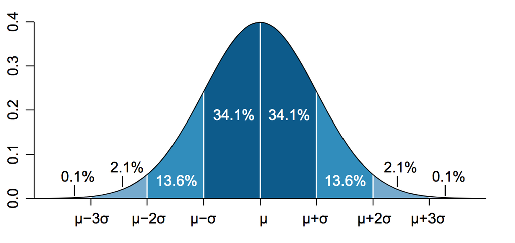

### Parte 1. **Posición**

Veamos los datos sobre accidentes nuevamente:

```r
link2='https://docs.google.com/spreadsheets/d/e/2PACX-1vSKuD4fkPOCgoRhefu9cDLzKJe-tkZ8V0EDPihgr2B6PZK3j-MGAfcSyNRQ91hzhuEh_iCebo1-8DWu/pub?gid=1869012038&single=true&output=csv'

accidentes=read.csv(link2, stringsAsFactors = F)
#
str(accidentes)
```

```
## 'data.frame':    33 obs. of  10 variables:
##  $ EMPRESA    : chr  "Volcan" "Buenaventura" "Ananea" "Atacocha" ...
##  $ a2000      : int  4 2 0 2 4 2 1 3 2 0 ...
##  $ a2001      : int  12 3 2 6 2 1 3 0 1 2 ...
##  $ a2002      : int  0 4 8 2 0 3 3 3 1 2 ...
##  $ a2003      : int  5 3 0 1 4 3 4 2 3 6 ...
##  $ a2004      : int  3 1 1 1 2 4 3 1 3 2 ...
##  $ a2005      : int  6 7 5 4 2 3 2 3 2 0 ...
##  $ a2006      : int  12 3 4 3 2 0 0 2 1 1 ...
##  $ Responsable: chr  "Contrata" "Contrata" "Contrata" "Contrata" ...
##  $ Tama       : chr  "Grande" "Mediana" "Pequeña" "Mediana" ...
```

Sumemos la cantidad de accidentes por año, del 2000 al 2006:

```r
# comando "rowSums"
# aplicandolo de la columna 2 hasta la 8 inclusive
accidentes$totalAcci=rowSums(accidentes[,c(2:8)])

#este es el resultado de la columna nueva
accidentes$totalAcci
```

```
##  [1] 42 23 20 19 16 16 16 14 13 13 13 12 10 10 10  8  8  8  7  7  7  6  6
## [24]  6  5  5  5  5  5  5  5  5  5
```

Grafiquemos esos datos en un boxplot:

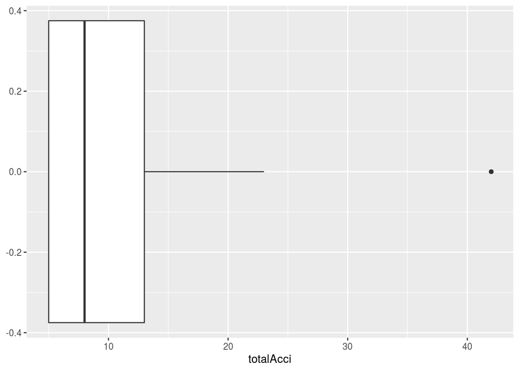

```r
library(ggplot2)
base=ggplot(accidentes,aes(y=totalAcci))
box= base + geom_boxplot() + coord_flip()
box
```

El boxplot es muy bueno para informarnos las posiciones. Calculamos los cuartiles:

```r
cuartiles=quantile(accidentes$totalAcci,probs = c(0.25,0.5,0.75))
cuartiles
```

```
## 25% 50% 75%
##   5   8  13
```

Esos son los valores representados por la caja central.

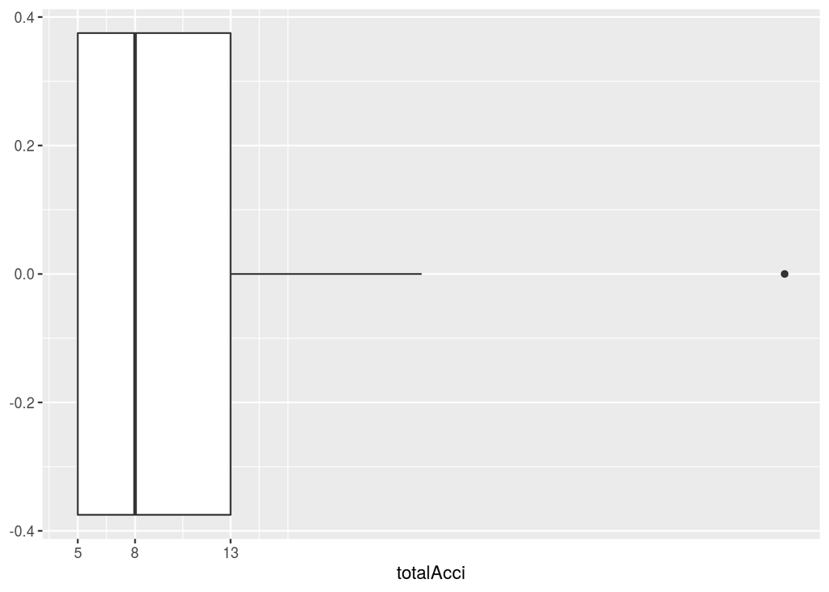

```r
box+ scale_y_continuous(breaks=as.vector(cuartiles))
```

De ahí, sabemos que el 25% de los valores más bajos no supera 5 accidentes, y que el 25% de los más altos no baja de 13 accidentes. Recuerda que la mediana es el cuartil 2.

El valor a la derecha, representado por un punto, representa un valor **atípico**. Ante la presencia de atípicos, la mediana es más informativa que la media.

Si deseas verlo en el histograma:

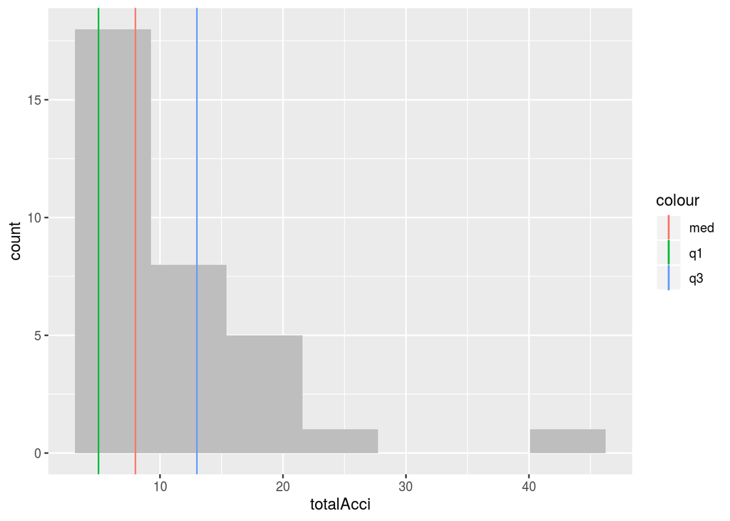

```r
base=ggplot(accidentes,aes(x=totalAcci))

histNum= base + geom_histogram(bins=7,fill='gray')
histNum + geom_vline(aes(xintercept = cuartiles[1],color="q1")) +
          geom_vline(aes(xintercept = cuartiles[2],color="med")) +
          geom_vline(aes(xintercept = cuartiles[3],color="q3"))
```

### Parte 2. **Apuntamiento o Curtosis**

Usemos un histograma teniendo como fondo la curva normal:

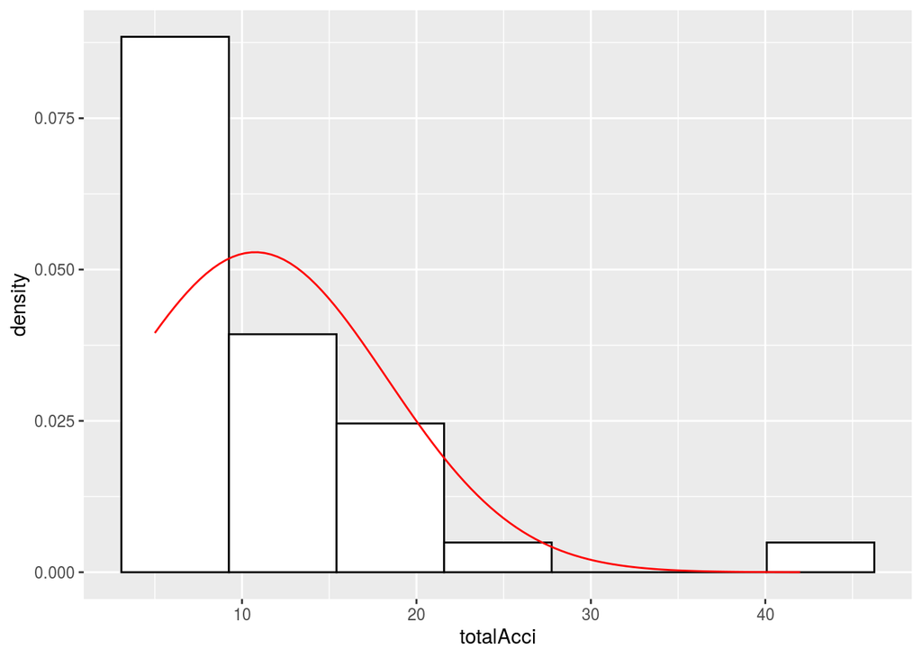

```r
base + geom_histogram(aes(y =..density..), bins=7,
                   colour = "black",
                   fill = "white") +
stat_function(fun = dnorm,args = list(mean = mean(accidentes$totalAcci),
                                      sd = sd(accidentes$totalAcci)),
              col='red')
```

Esto nos sugiere que hay mucho apuntamiento, verifiquemos si se obtiene un valor positivo:

```r
library(DescTools)
set.seed(123)
Kurt(accidentes$totalAcci,conf.level = 0.05, ci.type = 'bca', method = 2)
```

```
##      kurt    lwr.ci    upr.ci
##  8.346254 11.640519 12.296337
```

R te dice aquí que el coeficiente de curtosis para estos datos; y también te informa donde estaría el verdadero valor en poblaciones de este tipo. Si el intervalo tocase el cero, es probable que no haya curtosis en estos datos.

### Parte 3. **Asimetría**

La asimetría informa la presencia de colas hacia la derecha o la izquierda. Como los valores extremos producen asimetría, ya los gráficos anteriores nos informan que hay una cola a la derecha. En esas situaciones, el coeficiente de asimetría debe ser positivo:

```r
Skew(accidentes$totalAcci,conf.level = 0.05, ci.type = 'bca')
```

```
##     skew   lwr.ci   upr.ci
## 2.251112 2.574013 2.652273
```

La asimetría positiva se confirma por que el intervalo de coeficiente no toca el cero.

Recordemos este histograma:

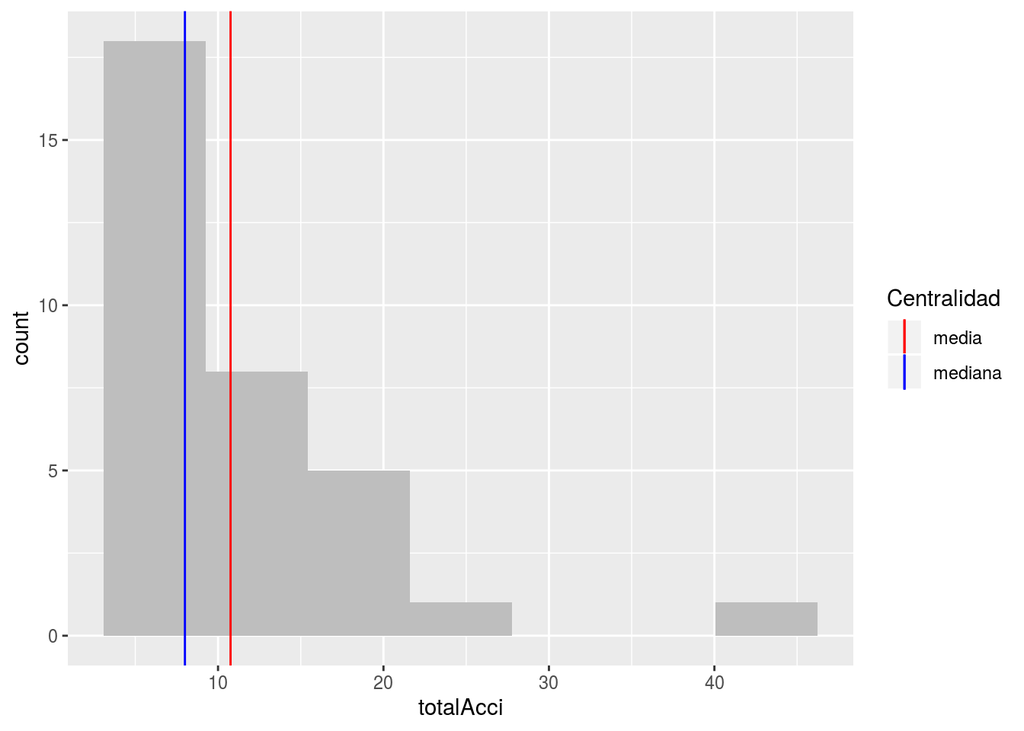

```r
base=ggplot(accidentes,aes(x=totalAcci))

histNum= base + geom_histogram(bins=7,fill='gray')
histNum +geom_vline(aes(xintercept = mean(accidentes$totalAcci, na.rm = T),color="media")) +
         geom_vline(aes(xintercept = median(accidentes$totalAcci, na.rm = T),color="mediana")) +
         scale_color_manual(name = "Centralidad", values = c(mediana = "blue", media = "red"))
```

Recuerda que la asimetría positiva hace que la media sea mayor que la mediana. Si hubiera sido negativa, la mediana es mayor que la media.

**Ejercicio:**

1. Utilice sus datos y calcule las medidas que correspondan.
2. Llene esta encuesta:

[interactive chart not shown]

3. vea data [AQUI](https://docs.google.com/spreadsheets/d/1vfBLwrm8eMFgS6REbMskcQbtiC5nXQEdixkRXMkDhoY/edit?usp=sharing)

[Volver al programa del curso](https://coursesandtutorials.github.io/Estadistica/)